# RLab1 due on Sep 09

First Name, Last Name

8/30/2021

## Instructions

You are expected to complete this homework in R by using this Rmarkdown file in RStudio environment. Create a new folder in your computer and save this Rmarkdown file and the Data_RLab1.csv file in the same folder.

Submission instructions: Submit the Rmarkdown file and the html or pdf format of your knitted output.

0. *[2 points]* Write your full name in the “Author” part above and save as this Rmarkdown file by adding your initials to the end (i.e., RLab1_LB.Rmd)

```r
#title: "RLab1 due on Sep 09 "
#author: "Nitiphong, Nirachornkul"
#date: "8/31/2021"
#output: html_document
```

## Intro

In this Lab assignment, we will use data from the U.S. Dept. of Education College scorecard. Data is in csv file. We will import it to R format and name the dataset as schools by using the read.csv command, shown below, and in cases where any cell takes the value of “NULL” or “PrivacySuppressed”, we will code them NA.

```r
if (!require("knitr")) install.packages("knitr")
library(knitr)
schools <- read.csv("Data_RLab1.csv", na = c("NULL", "PrivacySuppressed"))
```

Data is messy. There are 7149 observations and 1778 variables.

For the sake of this lab assignment, we will only keep the following 6 variablest.

1. CONTROL - onwnership type (public, private - NP, private - P) 2.C150_4 - Completion/graduation rate 3.PREDDEG - Predominat type of degree awarded
2. SAT_AVG - average SAT score of students admitted
3. UGDS - Enrollment of undergraduat certificate/degree-seeking students 6.COSTT4_A - Average cost of attendance (academic year institutions)

We will use the following code to keep only the above 6 variables and call the reduced dataset schools_subset.

```r
library(knitr)
library(dplyr)
schools_subset  <- subset(schools, select =c(CONTROL,  C150_4, PREDDEG,SAT_AVG, UGDS, COSTT4_A))

head(schools_subset)
```

```
##   CONTROL C150_4 PREDDEG SAT_AVG  UGDS COSTT4_A
## 1       1 0.2875       3     851  4483    13242
## 2       1 0.3958       3    1107 10265    16955
## 3       2 0.0000       3      NA   389    20100
## 4       1 0.4755       3    1145  5956    16876
## 5       1 0.2174       3     805  4638    14000
## 6       1 0.6593       3    1122 23296    20496
```

# Prepare the Data

1. *[8 points]* Write an R code below to keep only predominantly bachelor’s degree granting schools ($PREDDEG=='3'$).

```r
library(dplyr)
bachelor <- filter(schools, schools$PREDDEG=='3')
```

What are the dimensions of the filtered data (number of rows and columns)? *

```r
#number of rows : 2061
#number of columns : 1778
```

2. *[10 points]* How many missing values do we have for each variable in the filtered data set? Write an R code below to calculate the total number of missing values for each variable.

```r
print("The total number of missing values for each variable ")
```

```
## [1] "The total number of missing values for each variable "
```

```r
for (var in 1:1778)
{
    summation <- (sum(is.na(schools[,var])))
    name <- colnames(schools[var])
    print(paste(name," = ",summation))
}
```

```
## [1] "UNITID  =  0"
## [1] "OPEID  =  0"
## [1] "OPEID6  =  0"
## [1] "INSTNM  =  0"
## [1] "CITY  =  0"
## [1] "STABBR  =  0"
## [1] "ZIP  =  0"
## [1] "ACCREDAGENCY  =  7149"
## [1] "INSTURL  =  7149"
## [1] "NPCURL  =  7149"
## [1] "SCH_DEG  =  111"
## [1] "HCM2  =  7149"
## [1] "MAIN  =  0"
## [1] "NUMBRANCH  =  0"
## [1] "PREDDEG  =  0"
```

[output cut: 1763 more lines]

```r
print(paste("The total NULL for all variable = ",sum(is.na(bachelor))))
```

```
## [1] "The total NULL for all variable =  1846523"
```

3. *[10 points]* Now, write an R code to drop observations when C150_4 variable has missing values.  
   What are the dimensions of the filtered data (number of rows and columns) after dropping the cases with missing values?

```r
#C150_4 <- schools$C150_4 %>% na.omit()
C150_4 <- filter(schools, schools$C150_4 != 'na')
print(count(C150_4,'isnull'))
```

```
##   "isnull"    n
## 1   isnull 2269
```

```r
#df [2,269 x 1,778]
```

4. *[10 points]* Now, your task is to impute (replace) missing values in SAT_AVG and COSTT4_A with their median scores.

Write an R code below to impute the missing SAT_AVG and COSTT4_A values with their corresponding median values.

When you calculate the median for each variable, ignore the NAs. Write an R code what shows that you have zero missing values after the imputation.

```r
median_SAT_AVG <- median(schools$SAT_AVG, na.rm = TRUE)
schools$SAT_AVG[is.na(schools$SAT_AVG)] = median_SAT_AVG

median_COSTT4_A <- median(schools[,177], na.rm = TRUE)
schools$COSTT4_A[is.na(schools$COSTT4_A)] = median_COSTT4_A
print(sum(is.na(schools$SAT_AVG)))
```

```
## [1] 0
```

```r
print(sum(is.na(schools$COSTT4_A)))
```

```
## [1] 0
```

5. *[10 points]* Now, we will do some graphical analysis on the data. Before doing it, let’s drop PREDDEG from the data set and rename some variables as follows:  
   Rename SAT_AVG to SAT

Rename C150_4 to graduation_rate

Rename UGDS to enrollment

Rename COSTT4_A to cost

Write an R code below to drop PREDDEG and rename the variables as indicated above.

```r
#schools<- subset(schools, select = -PREDDEG)

names(schools)[59] = 'SAT'

variables <- as.integer(match("C150_4",names(schools)))
names(schools)[variables] = 'graduation_rate'

variables <- as.integer(match("UGDS",names(schools)))
names(schools)[variables] = 'enrollment'

variables <- as.integer(match("COSTT4_A",names(schools)))
names(schools)[variables] = 'cost'
```

6. *[10 points]*

Now, write an R code to treat CONTROL variable as a factor (currently, R treats CONTROL variable as an integer).

Then, Use the plot() function to produce side-by-side boxplots of cost versus CONTROL and

side-by-side boxplots of graduation_rate versus CONTROL. Do you see any pattern?

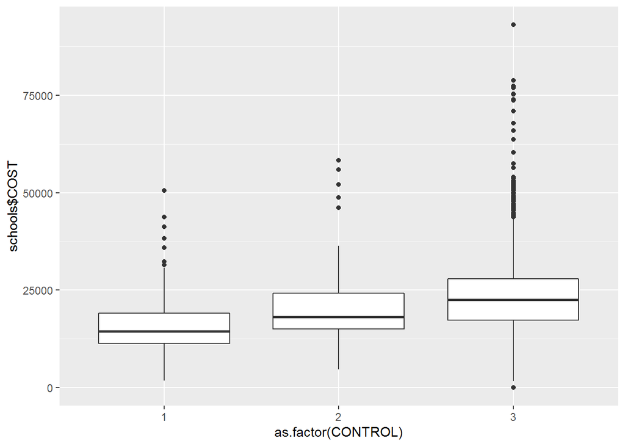

```r
library(ggplot2)

ggplot(schools, aes(x =as.factor(CONTROL), y = schools$COST)) + geom_boxplot()
```

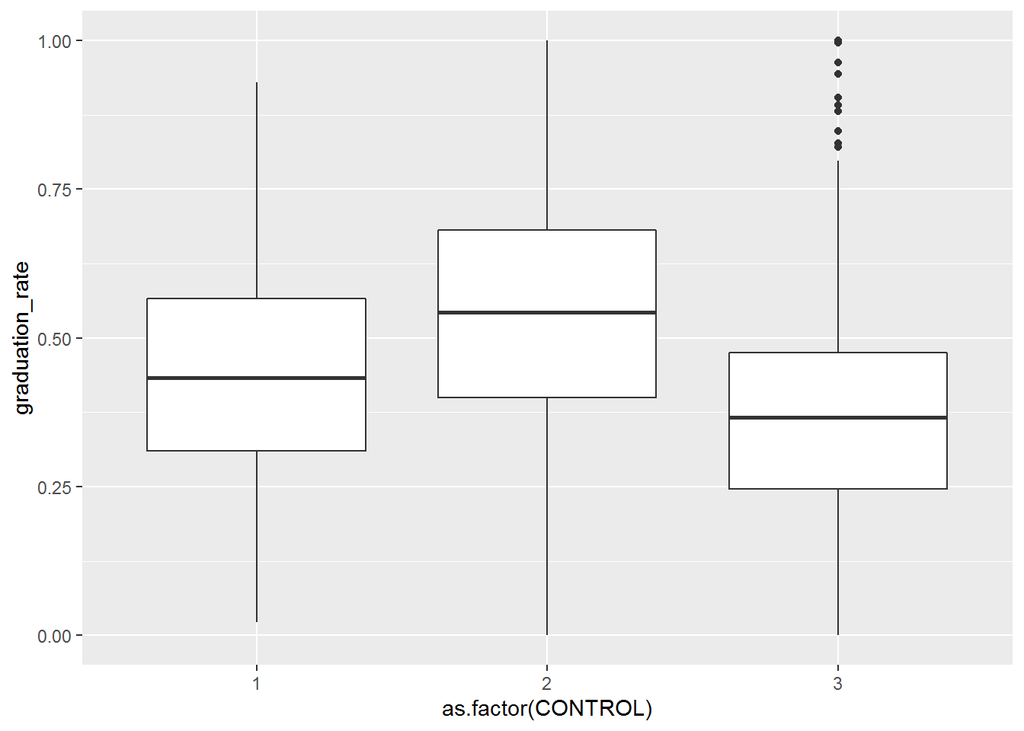

```r
ggplot(schools, aes(x =as.factor(CONTROL), y= graduation_rate)) + geom_boxplot()
```

7. *[10 points]* Write and R code to detect and remove observations, if any, that lie outside the interquartile range for enrollment, cost, graduation_rate and SAT variables

```r
IQR(schools$enrollment, na.rm = TRUE)
```

```
## [1] 2105
```

```r
IQR(schools$cost, na.rm = TRUE)
```

```
## [1] 21040
```

```r
IQR(schools$graduation_rate, na.rm = TRUE)
```

```
## [1] 0.2904
```

```r
IQR(schools$SAT, na.rm = TRUE)
```

```
## [1] 2
```

8.*[20 points]* By using R, 8.1 construct some plots

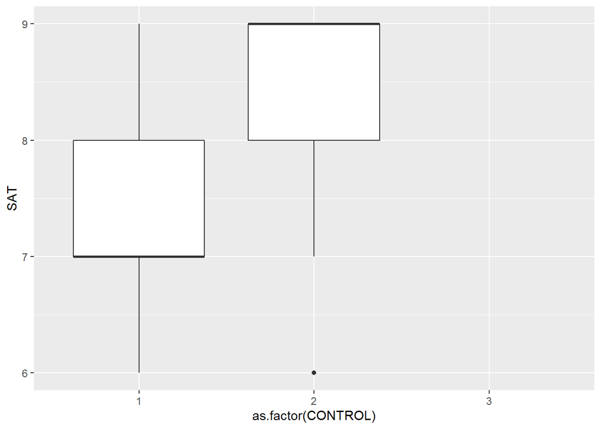

```r
ggplot(schools, aes(x= as.factor(CONTROL), y = SAT)) + geom_boxplot()
```

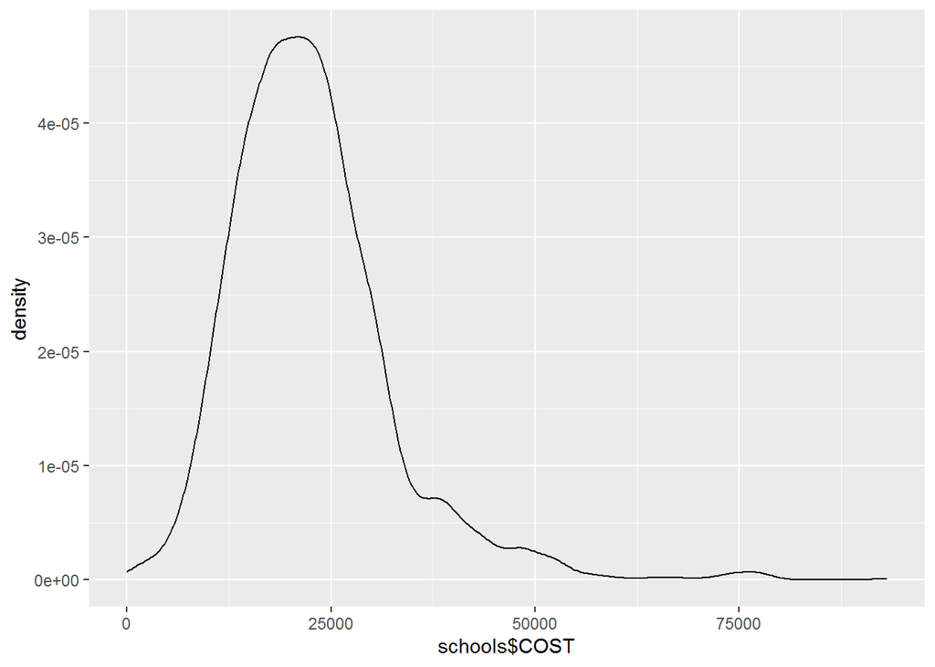

```r
ggplot(schools, aes(x=schools$COST)) + geom_density()
```

8.2 create summary statistics table

```r
df1 <- summary(schools[,c(59,387,291,377)])
print(df1)
```

```
##       SAT        graduation_rate   enrollment          cost
##  Min.   :6.000   Min.   :0.000   Min.   :     0   Min.   :    0
##  1st Qu.:7.000   1st Qu.:0.338   1st Qu.:   139   1st Qu.:    0
##  Median :8.000   Median :0.475   Median :   619   Median : 9395
##  Mean   :7.945   Mean   :0.483   Mean   :  2500   Mean   :12021
##  3rd Qu.:9.000   3rd Qu.:0.629   3rd Qu.:  2244   3rd Qu.:21040
##  Max.   :9.000   Max.   :1.000   Max.   :235028   Max.   :58535
##  NA's   :7076    NA's   :4880    NA's   :553
```

8.3 correlation plots

```r
library("Hmisc")
library("PerformanceAnalytics")
my_data <- as.matrix(schools[,c(59,387,291,377)])
rcorr(my_data, type = c("pearson","spearman"))
```

```
##                   SAT graduation_rate enrollment cost
## SAT              1.00            0.83      -0.15 0.68
## graduation_rate  0.83            1.00       0.06 0.47
## enrollment      -0.15            0.06       1.00 0.14
## cost             0.68            0.47       0.14 1.00
##
## n
##                 SAT graduation_rate enrollment cost
## SAT              73              72         73   73
## graduation_rate  72            2269       2269 2269
## enrollment       73            2269       6596 6596
## cost             73            2269       6596 7149
##
## P
##                 SAT    graduation_rate enrollment cost
## SAT                    0.0000          0.1963     0.0000
## graduation_rate 0.0000                 0.0074     0.0000
## enrollment      0.1963 0.0074                     0.0000
## cost            0.0000 0.0000          0.0000
```

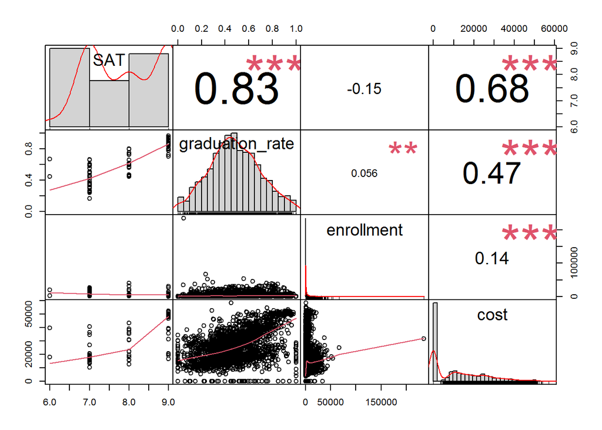

```r
chart.Correlation(my_data, histogram=TRUE, pch=19)
```

8.4 highlighting the relationships among the variables in our dataset comment on your findings.

```r
#According to the chart, SAT scores are very positive correlate with graduate_rate as 83% which means who can do high score on SAT also have high probability to graduate. Moreover, SAT and COST are relating to each other which mean who have high SAT have higher effort to pay tuition fee.
```

9.*[10 points]* Suppose that we want to understand what drives the graduation rate (graduation_rate) on the basis of the other variables in our dataset. Do your plots suggest that any of the other variables might be useful in predicting graduation_rate? Justify your answer.

```r
#According to the results of 4 factors correlation such as SAT, graduation,enrollment and cost, SAT scores correlation with graduation rate is the highest correlation. The second  highest correlation is cost which mean this two factors are more appropriate to be the independent factors on predictive model than enrollment.
```

Make sure that your R codes will run. Submit this Rmarkdown file on Canvas by September the 9th.